# Jalesh_DecisionTree

### since the data is already preprocessed and savedonto disc, I would be working on the preprocessed data and wud be implementing DT of different NLP vectorizers

**DT - BoW**

```python
#importing required packages

import numpy as np
import pandas as pd
import matplotlib.pyplot as plt
import seaborn as sns
import warnings
import scipy as sc
import sympy
import datetime
#import date
import os
import sys
import graphviz
%matplotlib inline
warnings.filterwarnings('ignore')
```

*importing performance metric libraries*

```python
#importing Logistic regression libraries:
from sklearn.tree import DecisionTreeClassifier

#train test split libaries:
from sklearn.preprocessing import StandardScaler
from sklearn.model_selection import train_test_split

#importing performance libraries:
from sklearn.metrics import f1_score
from sklearn.metrics import confusion_matrix
from sklearn.metrics import precision_score
from sklearn.metrics import precision_recall_curve
from sklearn.metrics import roc_curve
from sklearn.metrics import roc_auc_score
from sklearn.metrics import auc
```

*Imporing preprocessed cleaned data from database file*

```python
%%time
import sqlite3
con = sqlite3.connect('/home/reachjalesh/PreprocessingFolder/final_1L.sqlite')
df = pd.read_sql_query("""select * from reviews""", con)
```

```
CPU times: user 1.21 s, sys: 372 ms, total: 1.58 s
Wall time: 3.21 s
```

```python
len(df)
```

```
100000
```

```python
df.columns
```

```
Index(['index', 'Id', 'ProductId', 'UserId', 'ProfileName',
       'HelpfulnessNumerator', 'HelpfulnessDenominator', 'Score', 'Time',
       'Summary', 'Text', 'CleanedText_Bow', 'ClenedText_W2Vtfdf', 'Bow_feat',
       'Bow_new_feat', 'w2v_feat', 'w2v_new_feat'],
      dtype='object')
```

```python
df.Bow_new_feat.head(2)
```

```
0    everi book educ witti littl book make son laug...
1    whole seri great way spend time child rememb s...
Name: Bow_new_feat, dtype: object
```

```python
df.Bow_feat.head(2)
```

```
0                          everi book educ
1    whole seri great way spend time child
Name: Bow_feat, dtype: object
```

```python
df.CleanedText_Bow.head(2)
```

```
0    witti littl book make son laugh loud recit car...
1    rememb see show air televis year ago child sis...
Name: CleanedText_Bow, dtype: object
```

```python
vectorizer = ['bow']
for i in vectorizer:
    print('unfeatured preprocesed column for vectorizer: {} is: \n {}'.format(i, df.CleanedText_Bow.head(1)))
    print()
    print('featured preprocesed column for vectorizer: {} is: \n {}'.format(i, df.Bow_new_feat.head(1)))
```

```
unfeatured preprocesed column for vectorizer: bow is:
 0    witti littl book make son laugh loud recit car...
Name: CleanedText_Bow, dtype: object

featured preprocesed column for vectorizer: bow is:
 0    everi book educ witti littl book make son laug...
Name: Bow_new_feat, dtype: object
```

```python
vectorizer = ['tfidf', 'avg-w2v', 'tfidf-w2v']
for i in vectorizer:
    print('UNFEATURED COLUMN for vectorizer: {} is: \n {}'.format(i, df.Text.head(1)))
    print()
    print('FEATURED COLUMN for vectorizer: {} is: \n {}'.format(i, df.ClenedText_W2Vtfdf.head(1)))
```

```
UNFEATURED COLUMN for vectorizer: tfidf is:
 0    this witty little book makes my son laugh at l...
Name: Text, dtype: object

FEATURED COLUMN for vectorizer: tfidf is:
 0    witty little book makes son laugh loud recite ...
Name: ClenedText_W2Vtfdf, dtype: object
UNFEATURED COLUMN for vectorizer: avg-w2v is:
 0    this witty little book makes my son laugh at l...
Name: Text, dtype: object

FEATURED COLUMN for vectorizer: avg-w2v is:
 0    witty little book makes son laugh loud recite ...
Name: ClenedText_W2Vtfdf, dtype: object
UNFEATURED COLUMN for vectorizer: tfidf-w2v is:
 0    this witty little book makes my son laugh at l...
Name: Text, dtype: object

FEATURED COLUMN for vectorizer: tfidf-w2v is:
 0    witty little book makes son laugh loud recite ...
Name: ClenedText_W2Vtfdf, dtype: object
```

```python
for i in df.ClenedText_W2Vtfdf.head(1):
    print(i)
print('\n' * 2)
for i in df.Text.head(1):
    print(i)
```

```
witty little book makes son laugh loud recite car driving along always sing refrain learned whales india drooping love new words book introduces silliness classic book willing bet son still able recite memory college



this witty little book makes my son laugh at loud  i recite it in the car as we re driving along and he always can sing the refrain  he s learned about whales  india  drooping roses:  i love all the new words this book  introduces and the silliness of it all   this is a classic book i am  willing to…
```

*sorting dataframe based on time*

```python
#sorting the datframe based on time:
print(len(df))
df = df.sort_values('Time', ascending=True)
print()
df['Time'].head(8)
```

```
100000
```

```
0    939340800
1    940809600
2    944092800
3    944438400
4    946857600
5    947376000
6    948240000
7    948672000
Name: Time, dtype: int64
```

```python
len(df)
```

```
100000
```

```python
df.columns
```

```
Index(['index', 'Id', 'ProductId', 'UserId', 'ProfileName',
       'HelpfulnessNumerator', 'HelpfulnessDenominator', 'Score', 'Time',
       'Summary', 'Text', 'CleanedText_Bow', 'ClenedText_W2Vtfdf', 'Bow_feat',
       'Bow_new_feat', 'w2v_feat', 'w2v_new_feat'],
      dtype='object')
```

```python
df.Score.value_counts()
```

```
1    87729
0    12271
Name: Score, dtype: int64
```

**train test split**

```python
xtrain, xtest, ytrain, ytest = train_test_split(df.Bow_new_feat, df.Score, test_size=0.2, shuffle=False)
xtr, xcv, ytr, ycv = train_test_split(xtrain, ytrain, test_size=0.2, shuffle=False)
```

*BoW object instantiation*

```python
from sklearn.feature_extraction.text import CountVectorizer

bow_object = CountVectorizer(ngram_range=(1,1))

xtr = bow_object.fit_transform(xtr)
xcv = bow_object.transform(xcv)
xtest = bow_object.transform(xtest)


print(xtr.shape)
print(xcv.shape)
print(xtest.shape)
```

```
(64000, 31265)
(16000, 31265)
(20000, 31265)
```

# 1. DT on BoW

```python
class decisiontree:

    '''building the decision tree classifier based off various parameters'''

    #instantiating the instance attributes:
    def __init__(self, xtr, ytr, xcv, ycv, minimum_splits=[5,10,100,500], maximum_depth=[1, 5, 10, 50, 100, 500, 100]):
        self.xtr = xtr
        self.ytr = ytr
        self.xcv = xcv
        self.ycv = ycv
        self.minimum_splits = minimum_splits
        self.maximum_depth = maximum_depth

    #creating a method of calling DT classifier:
    def classfier(self, auc_dict_cv={}, auc_dict_tr={}):
        for splits in self.minimum_splits:
            for depths in self.maximum_depth:
                clf = DecisionTreeClassifier(max_depth=depths, min_samples_split=splits)
                print(depths, splits)
                clf.fit(self.xtr, self.ytr)
                y_pred_cv = clf.predict_proba(self.xcv)

                #performance metric on CV data:
                fpr_cv, tpr_cv, thresholds_cv = roc_curve(ycv, y_pred_cv[:,1])
                auc_val = auc(fpr_cv, tpr_cv)
                auc_dict_cv[zip([splits], [depths])] = auc_val

                #performance metrics for training data:
                y_pred_tr = clf.predict_proba(self.xtr)
                fpr_tr, tpr_tr, thresholds_tr = roc_curve(ytr, y_pred_tr[:,1])
                auc_val = auc(fpr_tr, tpr_tr)
                auc_dict_tr[zip([splits], [depths])] = auc_val

        return auc_dict_tr, auc_dict_cv
```

# BoW decision tree instance creation on training and CV data

```python
%time
BoW_instance = decisiontree(xtr, ytr, xcv, ycv)

dictionary_train, dictionary_cv = BoW_instance.classfier()
```

```
CPU times: user 0 ns, sys: 0 ns, total: 0 ns
Wall time: 5.48 µs
1 5
5 5
10 5
50 5
100 5
500 5
100 5
1 10
5 10
10 10
50 10
100 10
500 10
100 10
1 100
5 100
10 100
50 100
100 100
500 100
100 100
1 500
5 500
10 500
50 500
100 500
500 500
100 500
```

```python
train_list = [(list(x), np.round(y,3)) for x, y in dictionary_train.items()]
cv_list = [(list(x), np.round(y,3)) for x, y in dictionary_cv.items()]
```

```python
print(train_list[0])

print()
print(cv_list[0])
```

```
([(500, 10)], 0.816)

([(5, 5)], 0.757)
```

**sorting the list based off AUC score**

```python
tr_list = sorted(train_list, key=lambda x: x[1], reverse=True)
cv_list = sorted(cv_list, key=lambda x: x[1], reverse=True)
print('sorted train list score based off AUC score is:\n', tr_list[0:3])
print('****************************************')
print('sorted train list score based off AUC score is:\n', cv_list[0:3])
```

```
sorted train list score based off AUC score is:
 [([(5, 500)], 1.0), ([(10, 500)], 0.998), ([(5, 100)], 0.99)]
sorted train list score based off AUC score is:
 [([(500, 50)], 0.855), ([(500, 100)], 0.845), ([(500, 100)], 0.843)]
```

*Plotting AUC Curve on training and cv data based off depth*

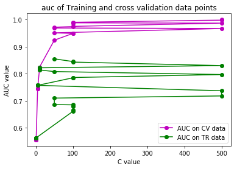

```python
plt.plot([x[0][0][1] for x in tr_list], [x[1] for x in tr_list], linestyle='-', color='m', marker='o',label='AUC on CV data')
plt.plot([x[0][0][1] for x in cv_list], [x[1] for x in cv_list], linestyle='-', color='g', marker='o', label='AUC on TR data')
#plt.plot([0, 1], [0, 1], linestyle='--')
plt.xlabel("C value")
plt.ylabel('AUC value')
plt.title('auc of Training and cross validation data points')
plt.legend()
```

# OptimalBoW - DecesionTree[depth = 50 and splits = 500]

```python
dt = DecisionTreeClassifier(max_depth=50, min_samples_split=500, class_weight='balanced')
dt.fit(xtr, ytr)

ypred = dt.predict_proba(xtest)
y_pred_tr = dt.predict_proba(xtr)

fpr_test, tpr_test, thresholds_test= roc_curve(ytest, ypred[:,1])
auc_test = auc(fpr_test, tpr_test)

print(auc_test)
```

```
0.8465095382508484
```

*plotting confusion matrix on test data*

```
CPU times: user 0 ns, sys: 0 ns, total: 0 ns
Wall time: 5.72 µs
```

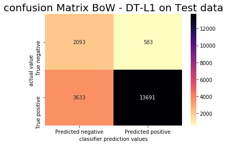

```python
%time
ypred = np.where(ypred[:,1] < 0.5, 0, 1)
#creating confusion matrix:

cf = confusion_matrix(ytest, ypred)
labels = ['True negative', 'True positive']

df_cf = pd.DataFrame(cf, index=labels, columns=['Predicted negative', 'Predicted positive'])
sns.heatmap(df_cf, annot=True,fmt='3d', cmap='magma_r')

plt.title("confusion Matrix BoW - DT-L1 on Test data", size=20)
plt.xlabel("classifier prediction values")
plt.ylabel("actual value")
plt.show()
```

*plotting confusion matrix on training data*

```
CPU times: user 0 ns, sys: 0 ns, total: 0 ns
Wall time: 5.72 µs
```

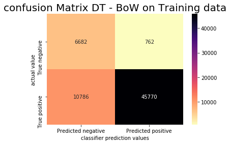

```python
%time
y_pred_tr = np.where(y_pred_tr[:,1] < 0.5, 0, 1)
#creating confusion matrix:

cf = confusion_matrix(ytr, y_pred_tr)
labels = ['True negative', 'True positive']

df_cf = pd.DataFrame(cf, index=labels, columns=['Predicted negative', 'Predicted positive'])
sns.heatmap(df_cf, annot=True,fmt='3d', cmap='magma_r')

plt.title("confusion Matrix DT - BoW on Training data", size=20)
plt.xlabel("classifier prediction values")
plt.ylabel("actual value")
plt.show()
```

*plotting ROC curve on test data*

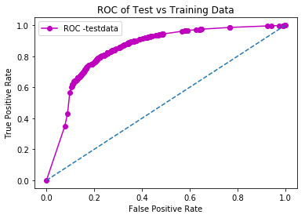

```python
plt.plot(fpr_test, tpr_test, color='m', marker='o',label='ROC -testdata')
plt.plot([0, 1], [0, 1], linestyle='--')
#plt.plot(fpr_tr, tpr_tr, linestyle='-', color='g', marker='o', label='ROC - training data')
plt.xlabel('False Positive Rate')
plt.ylabel('True Positive Rate')
plt.title('ROC of Test vs Training Data')
plt.legend()
```

**printing top 25 features of both positive and negative class**

```python
features = bow_object.get_feature_names()
featuresAndcoeff = sorted(zip(dt.feature_importances_, features))
top_features = zip(featuresAndcoeff[:25],featuresAndcoeff[:-(25+1): -1] )
print('\t\t\t\tNegative\t\t\t\t\t\t\tPositive')
print('-' * 120)

for (wn1, fn1), (wp1, fp1) in top_features:
    print('{:>20} {:>20}                                {:>20} {:>20}'.format(wn1, fn1, wp1, fp1))
```

```
				Negative							Positive
------------------------------------------------------------------------------------------------------------------------
                 0.0                  aaa                                 0.13948093745846474                great
                 0.0        aaaaaaaaagghh                                 0.13001810316688217                  not
                 0.0             aaaaaagh                                  0.0808721205363789                 best
                 0.0               aaaaah                                0.051088218985481874               delici
                 0.0 aaaaahhhhhhhhhhhhhhhh                                0.046033767601198164                 love
                 0.0                aaaah                                 0.03838207466207587           disappoint
                 0.0                 aaah                                 0.03257144975521582                 good
                 0.0               aaamaz                                0.029471152783491987                excel
                 0.0               aachen                                0.022677666208702856                  bad
                 0.0                  aad                                 0.02224952848379748              perfect
                 0.0                 aadp                                 0.01593856559068014              favorit
                 0.0                aafco                                0.010943421002860288                tasti
                 0.0                 aagh                                  0.0106602130864715                 nice
                 0.0                  aah                                0.010034615926634318                yummi
                 0.0                 aahh                                0.009726157264430612              horribl
                 0.0                 aand                                0.009420355588665231                   aw
                 0.0             aardvark                                0.007923216646274354               wonder
                 0.0                   ab                                0.0076688564431999316             unfortun
                 0.0                aback                                0.007432651745134353              thought
                 0.0               abacor                                0.006830754608818924              terribl
                 0.0               abaloo                                0.006119704429711919                money
                 0.0              abandon                                0.0060393132437182966                 tast
                 0.0              abaolut                                0.005586288520877951                howev
                 0.0             abattoir                                0.005417981818808328                 amaz
                 0.0                 abba                                 0.00424205980939696               addict
```

**since for negative class we are observing many features having feature importance values coming as 0,I m discarding all the features having 0 feature importance values and then printing the output of yop 25 features below:**

```python
features = bow_object.get_feature_names()
featuresAndcoeff = sorted(zip(dt.feature_importances_, features))
l = []
for a, b in featuresAndcoeff:
    if a == 0:
        continue
    else:
        l.append([a,b])

l = sorted(l, key=lambda x: x[0], reverse=True)
positive = l[:25]
negative = l[-(25 + 1): -1]
a = dict(top25_pos=positive,top25_neg=negative)
dataframe = pd.DataFrame(a)
dataframe
```

|  | top25_neg | top25_pos |
| --- | --- | --- |
| 0 | [0.00021228424577740033, sparkl] | [0.13948093745846474, great] |
| 1 | [0.00021210079852126024, elder] | [0.13001810316688217, not] |
| 2 | [0.00021191758895342224, tax] | [0.0808721205363789, best] |
| 3 | [0.0002117346166637638, proven] | [0.051088218985481874, delici] |
| 4 | [0.00021155188124377322, stabl] | [0.046033767601198164, love] |
| 5 | [0.00021145872075646526, grill] | [0.03838207466207587, disappoint] |
| 6 | [0.00021125268806688243, son] | [0.03257144975521582, good] |
| 7 | [0.00021104695634792175, decent] | [0.029471152783491987, excel] |
| 8 | [0.00021084152501623084, wheat] | [0.022677666208702856, bad] |
| 9 | [0.0002106363934864601, constip] | [0.02224952848379748, perfect] |
| 10 | [0.00021043156117435584, sens] | [0.01593856559068014, favorit] |
| 11 | [0.00021022702750007175, spicey] | [0.010943421002860288, tasti] |
| 12 | [0.0002100227918827855, opportun] | [0.0106602130864715, nice] |
| 13 | [0.00020981885374352522, depend] | [0.010034615926634318, yummi] |
| 14 | [0.000209411867589231, guilt] | [0.009726157264430612, horribl] |
| 15 | [0.00020920881842388246, cure] | [0.009420355588665231, aw] |
| 16 | [0.00020542688790375736, grate] | [0.007923216646274354, wonder] |
| 17 | [0.00019758220787443478, terrif] | [0.0076688564431999316, unfortun] |
| 18 | [0.00019701638881093868, prepar] | [0.007432651745134353, thought] |
| 19 | [0.00019623328302354663, friend] | [0.006830754608818924, terribl] |
| 20 | [0.00019500042850709542, area] | [0.006119704429711919, money] |
| 21 | [0.00017714320052933188, avail] | [0.0060393132437182966, tast] |
| 22 | [0.0001613512245253714, mild] | [0.005586288520877951, howev] |
| 23 | [0.0001612459332059049, tendenc] | [0.005417981818808328, amaz] |
| 24 | [0.00016114074491472156, high] | [0.00424205980939696, addict] |

**using graphviz, calculating the conditions**

```python
from sklearn import tree
```

```python
clf = tree.DecisionTreeClassifier(max_depth=2, min_samples_split=50)
clf = clf.fit(xtr, ytr)
dot_data = tree.export_graphviz(clf, out_file=None)
graph = graphviz.Source(dot_data)
graph.render("BoW_DecisionTree.png")
```

```
'BoW_DecisionTree.png.pdf'
```

# TF-IDF

```python
df.columns
```

```
Index(['index', 'Id', 'ProductId', 'UserId', 'ProfileName',
       'HelpfulnessNumerator', 'HelpfulnessDenominator', 'Score', 'Time',
       'Summary', 'Text', 'CleanedText_Bow', 'ClenedText_W2Vtfdf', 'Bow_feat',
       'Bow_new_feat', 'w2v_feat', 'w2v_new_feat'],
      dtype='object')
```

```python
#train test split:

xt, xtest, yt, ytest = train_test_split(df.ClenedText_W2Vtfdf, df.Score, test_size=0.2, shuffle=False)
xtr, xcv, ytr, ycv = train_test_split(xt, yt, test_size=0.2, shuffle=False)
```

*tf-Idf featurizer*

```python
from sklearn.feature_extraction.text import TfidfVectorizer

tfidf_object = TfidfVectorizer(ngram_range=(1,1))
xtr = tfidf_object.fit_transform(xtr)
xcv = tfidf_object.transform(xcv)
xtest = tfidf_object.transform(xtest)
```

```python
xtr.shape, xcv.shape, xtest.shape
```

```
((64000, 43852), (16000, 43852), (20000, 43852))
```

**since I HAVE MADE A COMMON CLASS FOR ALL THE VECTORIZERS, USING THAT CLASS in here for instantiating tfidf object**

```python
class decisiontree:

    '''building the decision tree classifier based off various parameters'''

    #instantiating the instance attributes:
    def __init__(self, xtr, ytr, xcv, ycv, minimum_splits=[5,10,100,500], maximum_depth=[1, 5, 10, 50, 100, 500, 1000]):
        self.xtr = xtr
        self.ytr = ytr
        self.xcv = xcv
        self.ycv = ycv
        self.minimum_splits = minimum_splits
        self.maximum_depth = maximum_depth

    #creating a method of calling DT classifier:
    def classfier(self, auc_dict_cv={}, auc_dict_tr={}):
        for splits in self.minimum_splits:
            for depths in self.maximum_depth:
                clf = DecisionTreeClassifier(max_depth=depths, min_samples_split=splits)
                print(depths, splits)
                clf.fit(self.xtr, self.ytr)
                y_pred_cv = clf.predict_proba(self.xcv)

                #performance metric on CV data:
                fpr_cv, tpr_cv, thresholds_cv = roc_curve(ycv, y_pred_cv[:,1])
                auc_val = auc(fpr_cv, tpr_cv)
                auc_dict_cv[zip([splits], [depths])] = auc_val

                #performance metrics for training data:
                y_pred_tr = clf.predict_proba(self.xtr)
                fpr_tr, tpr_tr, thresholds_tr = roc_curve(ytr, y_pred_tr[:,1])
                auc_val = auc(fpr_tr, tpr_tr)
                auc_dict_tr[zip([splits], [depths])] = auc_val

        return auc_dict_tr, auc_dict_cv
```

# TFidf decision tree instance creation on training and CV data

```python
import time
start = time.time()
Tfidf_instance = decisiontree(xtr, ytr, xcv, ycv)

dictionary_train, dictionary_cv = Tfidf_instance.classfier()
end = time.time()

print('time is(in seconds): ', end - start)
```

[output not shown]

```python
#creating dictionary :
train_list = [(list(x), np.round(y,3)) for x, y in dictionary_train.items()]
cv_list = [(list(x), np.round(y,3)) for x, y in dictionary_cv.items()]


print(train_list[0])
print()
print(cv_list[0])
```

```
([(5, 1)], 0.617)

([(10, 500)], 0.686)
```

**sorting the list based off AUC score**

```python
tr_list = sorted(train_list, key=lambda x: x[1], reverse=True)
cv_list = sorted(cv_list, key=lambda x: x[1], reverse=True)
print('sorted train list score based off AUC score is:\n', tr_list[0:3])
print('****************************************')
print()
print('sorted train list score based off AUC score is:\n', cv_list[0:3])
```

```
sorted train list score based off AUC score is:
 [([(5, 500)], 1.0), ([(10, 500)], 0.999), ([(100, 500)], 0.989)]

sorted train list score based off AUC score is:
 [([(500, 50)], 0.811), ([(500, 100)], 0.794), ([(500, 100)], 0.79)]
```

*Plotting AUC Curve on training and cv data based off depth*

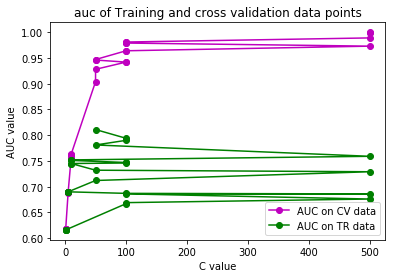

```python
plt.plot([x[0][0][1] for x in tr_list], [x[1] for x in tr_list], linestyle='-', color='m', marker='o',label='AUC on CV data')
plt.plot([x[0][0][1] for x in cv_list], [x[1] for x in cv_list], linestyle='-', color='g', marker='o', label='AUC on TR data')
#plt.plot([0, 1], [0, 1], linestyle='--')
plt.xlabel("C value")
plt.ylabel('AUC value')
plt.title('auc of Training and cross validation data points')
plt.legend()
```

# OptimalTFidf- DecesionTree[depth =50 and splits =500 ]

```python
dt = DecisionTreeClassifier(max_depth=50, min_samples_split=500, class_weight='balanced')
dt.fit(xtr, ytr)

ypred = dt.predict_proba(xtest)
ypred_tr = dt.predict_proba(xtr)


fpr_tr, tpr_tr, thresholds_tr= roc_curve(ytr, ypred_tr[:,1])
auc_tr = auc(fpr_tr, tpr_tr)


fpr_test, tpr_test, thresholds_test= roc_curve(ytest, ypred[:,1])
auc_test = auc(fpr_test, tpr_test)

print(auc_test)
```

```
0.795184547025839
```

*plotting confusion matrix on test data*

```
CPU times: user 0 ns, sys: 0 ns, total: 0 ns
Wall time: 6.44 µs
```

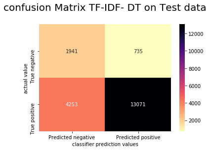

```python
%time
ypred = np.where(ypred[:,1] < 0.5, 0, 1)
#creating confusion matrix:

cf = confusion_matrix(ytest, ypred)
labels = ['True negative', 'True positive']

df_cf = pd.DataFrame(cf, index=labels, columns=['Predicted negative', 'Predicted positive'])
sns.heatmap(df_cf, annot=True,fmt='3d', cmap='magma_r')

plt.title("confusion Matrix TF-IDF- DT on Test data\n", size=20)
plt.xlabel("classifier prediction values")
plt.ylabel("actual value")
plt.show()
```

*plotting confusion matrix on training data*

```
CPU times: user 0 ns, sys: 0 ns, total: 0 ns
Wall time: 6.44 µs
```

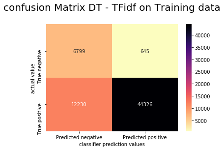

```python
%time
y_pred_tr = np.where(ypred_tr[:,1] < 0.5, 0, 1)
#creating confusion matrix:

cf = confusion_matrix(ytr, y_pred_tr)
labels = ['True negative', 'True positive']

df_cf = pd.DataFrame(cf, index=labels, columns=['Predicted negative', 'Predicted positive'])
sns.heatmap(df_cf, annot=True,fmt='3d', cmap='magma_r')

plt.title("confusion Matrix DT - TFidf on Training data\n", size=20)
plt.xlabel("classifier prediction values")
plt.ylabel("actual value")
plt.show()
```

*plotting ROC curve on test data and training data*

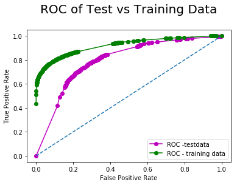

```python
plt.plot(fpr_test, tpr_test, color='m', marker='o',label='ROC -testdata')
plt.plot([0, 1], [0, 1], linestyle='--')
plt.plot(fpr_tr, tpr_tr, linestyle='-', color='g', marker='o', label='ROC - training data')
plt.xlabel('False Positive Rate')
plt.ylabel('True Positive Rate')
plt.title('ROC of Test vs Training Data\n', size=20)
plt.legend()
```

**printing top 25 features of both positive and negative class**

```python
features = tfidf_object.get_feature_names()
featuresAndcoeff = sorted(zip(dt.feature_importances_, features))
top_features = zip(featuresAndcoeff[:25],featuresAndcoeff[:-(25+1): -1] )
print('\t\t\t\tNegative\t\t\t\t\t\t\tPositive')
print('-' * 120)

for (wn1, fn1), (wp1, fp1) in top_features:
    print('{:>20} {:>20}                                {:>20} {:>20}'.format(wn1, fn1, wp1, fp1))
```

```
				Negative							Positive
------------------------------------------------------------------------------------------------------------------------
                 0.0                  aaa                                 0.10516368328831541                great
                 0.0        aaaaaaaaagghh                                 0.08981493578011883                  not
                 0.0               aaaaah                                 0.05636387210694428                 best
                 0.0 aaaaahhhhhhhhhhhhhhhh                                 0.03962773559888438            delicious
                 0.0                aaaah                                0.026029106587324068                 good
                 0.0                 aaah                                 0.02502140986757704                 love
                 0.0                aaahs                                 0.02222678208686428              perfect
                 0.0               aachen                                0.018976425351451484                loves
                 0.0                  aad                                0.018892614404691123             favorite
                 0.0                 aadp                                0.018042452974844997            excellent
                 0.0                aafco                                0.017859814717201716                  bad
                 0.0                 aagh                                0.017834669709603533            wonderful
                 0.0               aahhed                                0.016094524181307617                 nice
                 0.0               aahing                                0.013603866625851562         disappointed
                 0.0                 aand                                0.013554134169423238               highly
                 0.0             aardvark                                0.011454931690362291              thought
                 0.0                aback                                0.011186492407121829                tasty
                 0.0              abandon                                0.010775294933957291                 find
                 0.0            abandoned                                0.010101852442754114             terrible
                 0.0           abandoning                                0.009272475511591933        unfortunately
                 0.0           abaolutely                                0.009065122709265606                money
                 0.0             abattoir                                0.007893918145189327                 easy
                 0.0                 abba                                 0.00765073106257202                awful
                 0.0                abbey                                0.007017365346739904              however
                 0.0          abbreviated                                0.006380040216467915                taste
```

**since for negative class we are observing many features having feature importance values coming as 0,I m discarding all the features having 0 feature importance values and then printing the output of yop 25 features below:**

```python
features = tfidf_object.get_feature_names()
featuresAndcoeff = sorted(zip(dt.feature_importances_, features))
l = []
for a, b in featuresAndcoeff:
    if a == 0:
        continue
    else:
        l.append([a,b])

l = sorted(l, key=lambda x: x[0], reverse=True)
positive = l[:25]
negative = l[-(25 + 1): -1]
a = dict(top25_pos=positive,top25_neg=negative)
dataframe = pd.DataFrame(a)
dataframe
```

|  | top25_neg | top25_pos |
| --- | --- | --- |
| 0 | [0.00039993950958781333, prime] | [0.10516368328831541, great] |
| 1 | [0.0003990766917521303, play] | [0.08981493578011883, not] |
| 2 | [0.0003863104824043948, buy] | [0.05636387210694428, best] |
| 3 | [0.000382929778353476, feel] | [0.03962773559888438, delicious] |
| 4 | [0.0003698709445561861, store] | [0.026029106587324068, good] |
| 5 | [0.00036777760344292645, trouble] | [0.02502140986757704, love] |
| 6 | [0.00036514173476490737, difference] | [0.02222678208686428, perfect] |
| 7 | [0.0003645719717059419, reasonable] | [0.018976425351451484, loves] |
| 8 | [0.00036400354118198606, run] | [0.018892614404691123, favorite] |
| 9 | [0.0003634364390462109, finding] | [0.018042452974844997, excellent] |
| 10 | [0.00036287066116244885, plenty] | [0.017859814717201716, bad] |
| 11 | [0.00035137151050768523, wheat] | [0.017834669709603533, wonderful] |
| 12 | [0.0003375142606820132, yeast] | [0.016094524181307617, nice] |
| 13 | [0.00033638280253443537, stays] | [0.013603866625851562, disappointed] |
| 14 | [0.0003362727238730474, website] | [0.013554134169423238, highly] |
| 15 | [0.00031785281661207194, similar] | [0.011454931690362291, thought] |
| 16 | [0.0003174207432259656, biggest] | [0.011186492407121829, tasty] |
| 17 | [0.00031698955025107577, live] | [0.010775294933957291, find] |
| 18 | [0.0003165592352955709, robust] | [0.010101852442754114, terrible] |
| 19 | [0.0003161297959787346, heavy] | [0.009272475511591933, unfortunately] |
| 20 | [0.000315701229923574, pleasantly] | [0.009065122709265606, money] |
| 21 | [0.00031562967235673485, everything] | [0.007893918145189327, easy] |
| 22 | [0.0003112235624949291, recently] | [0.00765073106257202, awful] |
| 23 | [0.00030905502572903655, pretty] | [0.007017365346739904, however] |
| 24 | [0.000273979699052875, totally] | [0.006380040216467915, taste] |

**using graphviz for plotting the conditions, saving the same onto files**

```python
clf = tree.DecisionTreeClassifier(max_depth=3, min_samples_split=50)
clf = clf.fit(xtr, ytr)
dot_data = tree.export_graphviz(clf, out_file=None)
graph = graphviz.Source(dot_data)
graph.render("TFidf_DecisionTree")
```

```
'TFidf_DecisionTree.pdf'
```

# Avg-Word2Vec

```python
df.columns
```

```
Index(['index', 'Id', 'ProductId', 'UserId', 'ProfileName',
       'HelpfulnessNumerator', 'HelpfulnessDenominator', 'Score', 'Time',
       'Summary', 'Text', 'CleanedText_Bow', 'ClenedText_W2Vtfdf', 'Bow_feat',
       'Bow_new_feat', 'w2v_feat', 'w2v_new_feat'],
      dtype='object')
```

**train test cv split**

```python
xtrain, xtest, ytrain, ytest = train_test_split(df.ClenedText_W2Vtfdf, df.Score, test_size=0.2, shuffle=False)
xtr, xcv, ytr, ycv = train_test_split(xtrain, ytrain, test_size=0.2, shuffle=False)
```

*list of lists of train, cv, test data*

```python
%%time

#training list of words:
train_list = []
for sentence in xtr:
    tmp_list = []
    for word in sentence.split():
        tmp_list.append(word)
    train_list.append(tmp_list)

#cv list of words
cv_list = []
for sentence in xcv:
    tmp_list = []
    for word in sentence.split():
        tmp_list.append(word)
    cv_list.append(tmp_list)

#test list of words:
test_list = []
for sentence in xtest:
    tmp_list = []
    for word in sentence.split():
        tmp_list.append(word)
    test_list.append(tmp_list)
```

```
CPU times: user 1.19 s, sys: 160 ms, total: 1.35 s
Wall time: 1.35 s
```

*instantiating word2vec object for Train, cv, test data*

```python
%%time

from gensim.models import Word2Vec

#instantiating training,cv, test W2V object:

trainw2v = Word2Vec(train_list, size=1000)
cvw2v = Word2Vec(cv_list, size=1000)
testw2v = Word2Vec(test_list, size=1000)

#training word2vec List:
train_vocab = list(trainw2v.wv.vocab.keys())

#cv word2vec List:
cv_vocab = list(cvw2v.wv.vocab.keys())

#test word2vec List:
test_vocab = list(testw2v.wv.vocab.keys())
```

```
CPU times: user 1min 43s, sys: 332 ms, total: 1min 43s
Wall time: 1min 43s
```

*Avg-W2V for train, cv, test data*

```python
%%time

#avg-w2v for training data****************************:
train_vector = []
for sentence in train_list:
    vector = np.zeros(1000)
    for word in sentence:
        cnt = 0
        if word in train_vocab:
            vector = vector + trainw2v.wv[word]
            cnt = cnt + 1
    if cnt != 0:
        vector = vector / cnt
    train_vector.append(vector)

train_vector = np.array(train_vector)
print('train vector shape is {}'.format(train_vector.shape))


#avg-w2v for cv data***********************************:
cv_vector = []
for sentence in cv_list:
    vector = np.zeros(1000)
    for word in sentence:
        cnt = 0
        if word in cv_vocab:
            vector = vector + cvw2v.wv[word]
            cnt = cnt + 1
    if cnt != 0:
        vector = vector / cnt
    cv_vector.append(vector)

cv_vector = np.array(cv_vector)
print('cv vector shape is {}'.format(cv_vector.shape))




#avg-w2v for test data**********************************:
test_vector = []
for sentence in test_list:
    vector = np.zeros(1000)
    for word in sentence:
        cnt = 0
        if word in test_vocab:
            vector = vector + testw2v.wv[word]
            cnt = cnt + 1
    if cnt != 0:
        vector = vector / cnt
    test_vector.append(vector)

test_vector = np.array(test_vector)
print('test vector shape is {}'.format(test_vector.shape))
```

```
train vector shape is (64000, 1000)
cv vector shape is (16000, 1000)
test vector shape is (20000, 1000)
CPU times: user 12min 21s, sys: 1.66 s, total: 12min 23s
Wall time: 12min 24s
```

# since I HAVE MADE A COMMON CLASS FOR ALL THE VECTORIZERS, USING THAT CLASS in here for instantiating AvgW2V object

```python
class decisiontree:

    '''building the decision tree classifier based off various parameters'''

    #instantiating the instance attributes:
    def __init__(self, xtr, ytr, xcv, ycv, minimum_splits=[5,10,100,500], maximum_depth=[1, 5, 10, 50, 100, 500, 1000]):
        self.xtr = xtr
        self.ytr = ytr
        self.xcv = xcv
        self.ycv = ycv
        self.minimum_splits = minimum_splits
        self.maximum_depth = maximum_depth

    #creating a method of calling DT classifier:
    def classfier(self, auc_dict_cv={}, auc_dict_tr={}):
        for splits in self.minimum_splits:
            for depths in self.maximum_depth:
                clf = DecisionTreeClassifier(max_depth=depths, min_samples_split=splits)
                print(depths, splits)
                clf.fit(self.xtr, self.ytr)
                y_pred_cv = clf.predict_proba(self.xcv)

                #performance metric on CV data:
                fpr_cv, tpr_cv, thresholds_cv = roc_curve(ycv, y_pred_cv[:,1])
                auc_val = auc(fpr_cv, tpr_cv)
                auc_dict_cv[zip([splits], [depths])] = auc_val

                #performance metrics for training data:
                y_pred_tr = clf.predict_proba(self.xtr)
                fpr_tr, tpr_tr, thresholds_tr = roc_curve(ytr, y_pred_tr[:,1])
                auc_val = auc(fpr_tr, tpr_tr)
                auc_dict_tr[zip([splits], [depths])] = auc_val

        return auc_dict_tr, auc_dict_cv
```

# Avgw2v decision tree instance creation on training and CV data

```python
import time
start = time.time()
w2v_instance = decisiontree(train_vector, ytr, cv_vector, ycv)

dictionary_train, dictionary_cv = w2v_instance.classfier()
end = time.time()

print('time is(in seconds): ', end - start)
```

```
1 5
5 5
10 5
50 5
100 5
500 5
1000 5
1 10
5 10
10 10
50 10
100 10
500 10
1000 10
1 100
5 100
10 100
50 100
100 100
500 100
1000 100
1 500
5 500
10 500
50 500
100 500
500 500
1000 500
time is(in seconds):  3744.681820869446
```

```python
#creating dictionary :

train_list = [(list(x), np.round(y,3)) for x, y in dictionary_train.items()]
cv_list = [(list(x), np.round(y,3)) for x, y in dictionary_cv.items()]


print(train_list[0])
print()
print(cv_list[0])
```

```
([(100, 50)], 0.964)

([(100, 100)], 0.537)
```

**sorting the list based off AUC score**

```python
tr_list = sorted(train_list, key=lambda x: x[1], reverse=True)
cv_list = sorted(cv_list, key=lambda x: x[1], reverse=True)
print('sorted train list score based off AUC score is:\n', tr_list[0:3])
print('****************************************')
print()
print('sorted CV list score based off AUC score is:\n', cv_list[0:3])
```

```
sorted train list score based off AUC score is:
 [([(5, 500)], 1.0), ([(5, 50)], 1.0), ([(5, 1000)], 1.0)]

sorted CV list score based off AUC score is:
 [([(100, 5)], 0.627), ([(500, 5)], 0.627), ([(10, 5)], 0.627)]
```

*Plotting AUC Curve on training and cv data based off depth*

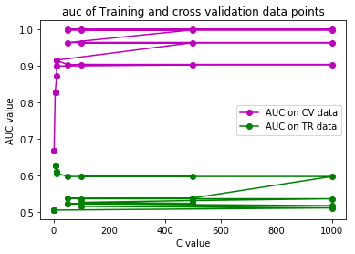

```python
plt.plot([x[0][0][1] for x in tr_list], [x[1] for x in tr_list], linestyle='-', color='m', marker='o',label='AUC on CV data')
plt.plot([x[0][0][1] for x in cv_list], [x[1] for x in cv_list], linestyle='-', color='g', marker='o', label='AUC on TR data')
#plt.plot([0, 1], [0, 1], linestyle='--')
plt.xlabel("C value")
plt.ylabel('AUC value')
plt.title('auc of Training and cross validation data points')
plt.legend()
```

# OptimalAvgW2V- DecesionTree[depth = 5 and splits = 100]

```python
dt = DecisionTreeClassifier(max_depth=5, min_samples_split=100, class_weight='balanced')
dt.fit(train_vector, ytr)

ypred = dt.predict_proba(test_vector)
ypred_tr = dt.predict_proba(train_vector)


fpr_tr, tpr_tr, thresholds_tr= roc_curve(ytr, ypred_tr[:,1])
auc_tr = auc(fpr_tr, tpr_tr)


fpr_test, tpr_test, thresholds_test= roc_curve(ytest, ypred[:,1])
auc_test = auc(fpr_test, tpr_test)

print(auc_test)
```

```
0.6617441622584633
```

*plotting confusion matrix on test data*

```
CPU times: user 0 ns, sys: 0 ns, total: 0 ns
Wall time: 7.63 µs
```

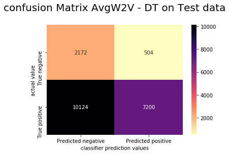

```python
%time
ypred = np.where(ypred[:,1] < 0.5, 0, 1)
#creating confusion matrix:

cf = confusion_matrix(ytest, ypred)
labels = ['True negative', 'True positive']

df_cf = pd.DataFrame(cf, index=labels, columns=['Predicted negative', 'Predicted positive'])
sns.heatmap(df_cf, annot=True,fmt='3d', cmap='magma_r')

plt.title("confusion Matrix AvgW2V - DT on Test data\n", size=20)
plt.xlabel("classifier prediction values")
plt.ylabel("actual value")
plt.show()
```

*plotting confusion matrix on training data*

```
CPU times: user 0 ns, sys: 0 ns, total: 0 ns
Wall time: 6.91 µs
```

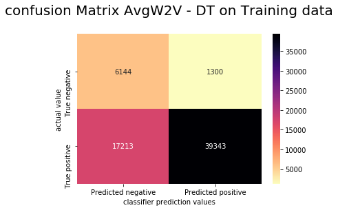

```python
%time
y_pred_tr = np.where(ypred_tr[:,1] < 0.5, 0, 1)
#creating confusion matrix:

cf = confusion_matrix(ytr, y_pred_tr)
labels = ['True negative', 'True positive']

df_cf = pd.DataFrame(cf, index=labels, columns=['Predicted negative', 'Predicted positive'])
sns.heatmap(df_cf, annot=True,fmt='3d', cmap='magma_r')

plt.title("confusion Matrix AvgW2V - DT on Training data\n", size=20)
plt.xlabel("classifier prediction values")
plt.ylabel("actual value")
plt.show()
```

*plotting ROC curve on test data and training data*

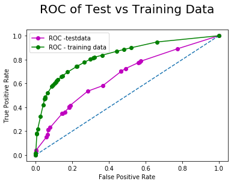

```python
plt.plot(fpr_test, tpr_test, color='m', marker='o',label='ROC -testdata')
plt.plot([0, 1], [0, 1], linestyle='--')
plt.plot(fpr_tr, tpr_tr, linestyle='-', color='g', marker='o', label='ROC - training data')
plt.xlabel('False Positive Rate')
plt.ylabel('True Positive Rate')
plt.title('ROC of Test vs Training Data\n', size=20)
plt.legend()
```

# TFidf-W2V

```python
%%time

from gensim.models import Word2Vec
from sklearn.feature_extraction.text import TfidfVectorizer

#train, cv, test split:
xtrain, xtest, ytrain, ytest = train_test_split(df.ClenedText_W2Vtfdf, df.Score, test_size=0.2, shuffle=False)
xtr, xcv, ytr, ycv = train_test_split(xtrain, ytrain, test_size=0.2, shuffle=False)


#training list of words:
train_list = []
for sentence in xtr:
    tmp_list = []
    for word in sentence.split():
        tmp_list.append(word)
    train_list.append(tmp_list)

#cv list of words:
cv_list = []
for sentence in xcv:
    tmp_list = []
    for word in sentence.split():
        tmp_list.append(word)
    cv_list.append(tmp_list)

#test list of words:
test_list = []
for sentence in xtest:
    tmp_list = []
    for word in sentence.split():
        tmp_list.append(word)
    test_list.append(tmp_list)


#instantiating training,cv, test W2V object:

trainw2v = Word2Vec(train_list, size=1000)
cvw2v = Word2Vec(cv_list, size=1000)
testw2v = Word2Vec(test_list, size=1000)

#training word2vec List:
train_vocab = list(trainw2v.wv.vocab.keys())

#cv word2vec List:
cv_vocab = list(cvw2v.wv.vocab.keys())

#test word2vec List:
test_vocab = list(testw2v.wv.vocab.keys())
```

```
CPU times: user 1min 54s, sys: 444 ms, total: 1min 54s
Wall time: 1min 54s
```

**Tfidf vectorizer**

```python
model = TfidfVectorizer()
xtr = model.fit_transform(xtr)
xcv = model.transform(xcv)
xtest = model.transform(xtest)

# we are converting a dictionary with word as a key, and the idf as a value
dictionary = dict(zip(model.get_feature_names(), list(model.idf_)))
```

```python
xtr.shape, xcv.shape, xtest.shape
```

```
((64000, 43848), (16000, 43848), (20000, 43848))
```

```python
len(train_list)
```

```
64000
```

*Creating TFIDF-W2V for training data,*

*TFIDF-W2V for cv data AND*

*TFIDF-W2V for test data*

```python
import time
start = time.time()

tfidf_feat = model.get_feature_names() # tfidf words/col-names
# final_tf_idf is the sparse matrix with row= sentence, col=word and cell_val = tfidf


#tf-idf for train data:
tfidf_train_vectors = []; # the tfidf-w2v for each sentence/review is stored in this list
row=0;
for sent in train_list: # for each review/sentence
    sent_vec = np.zeros(1000) # as word vectors are of zero length
    weight_sum =0; # num of words with a valid vector in the sentence/review
    for word in sent: # for each word in a review/sentence
        if word in train_vocab and word in tfidf_feat:
            vec = trainw2v.wv[word]
            tf_idf = dictionary[word]*(sent.count(word)/len(sent))
            sent_vec += (vec * tf_idf)
            weight_sum += tf_idf
    if weight_sum != 0:
        sent_vec /= weight_sum
    tfidf_train_vectors.append(sent_vec)
    row += 1

#######################################################################################################################

#tfidf for CV data:

tfidf_cv_vectors = []; # the tfidf-w2v for each sentence/review is stored in this list
row=0;
for sent in cv_list: # for each review/sentence
    sent_vec = np.zeros(1000) # as word vectors are of zero length
    weight_sum =0; # num of words with a valid vector in the sentence/review
    for word in sent: # for each word in a review/sentence
        if word in cv_vocab and word in tfidf_feat:
            vec = cvw2v.wv[word]
            tf_idf = dictionary[word]*(sent.count(word)/len(sent))
            sent_vec += (vec * tf_idf)
            weight_sum += tf_idf
    if weight_sum != 0:
        sent_vec /= weight_sum
    tfidf_cv_vectors.append(sent_vec)
    row += 1


#######################################################################################################################



tfidf_feat = model.get_feature_names() # tfidf words/col-names
# final_tf_idf is the sparse matrix with row= sentence, col=word and cell_val = tfidf


#tfidf for Test Data:

tfidf_test_vectors = []; # the tfidf-w2v for each sentence/review is stored in this list
row=0;
for sent in test_list: # for each review/sentence
    sent_vec = np.zeros(1000) # as word vectors are of zero length
    weight_sum =0; # num of words with a valid vector in the sentence/review
    for word in sent: # for each word in a review/sentence
        if word in test_vocab and word in tfidf_feat:
            vec = testw2v.wv[word]
            tf_idf = dictionary[word]*(sent.count(word)/len(sent))
            sent_vec += (vec * tf_idf)
            weight_sum += tf_idf
    if weight_sum != 0:
        sent_vec /= weight_sum
    tfidf_test_vectors.append(sent_vec)
    row += 1


end = time.time()

print('total time taken in seconds is: ', end - start)
```

```
total time taken in seconds is:  2726.192879676819
```

```python
# import pickle

# file1 = open('tfidfw2v_train.pickle', 'wb')
# pickle.dump(tfidf_train_vectors, file1)
# file1.close()

# file1 = open('tfidfw2v_cv.pickle', 'wb')
# pickle.dump(tfidf_cv_vectors, file1)
# file1.close()

# file1 = open('tfidfw2v_test.pickle', 'wb')
# pickle.dump(tfidf_test_vectors, file1)
# file1.close()
```

**conversion of list into array**

```python
xtr = np.array(tfidf_train_vectors)
xcv = np.array(tfidf_cv_vectors)
xtest = np.array(tfidf_test_vectors)

print(xtr.shape)
print(xcv.shape)
print(xtest.shape)
```

```
(64000, 1000)
(16000, 1000)
(20000, 1000)
```

**Tfidf-w2v DT CLASS creation**

```python
class decisiontree:

    '''building the decision tree classifier based off various parameters'''

    #instantiating the instance attributes:
    def __init__(self, xtr, ytr, xcv, ycv, minimum_splits=[5,10,100,500], maximum_depth=[1, 5, 10, 50, 100, 500]):
        self.xtr = xtr
        self.ytr = ytr
        self.xcv = xcv
        self.ycv = ycv
        self.minimum_splits = minimum_splits
        self.maximum_depth = maximum_depth

    #creating a method of calling DT classifier:
    def classfier(self, auc_dict_cv={}, auc_dict_tr={}):
        for splits in self.minimum_splits:
            for depths in self.maximum_depth:
                clf = DecisionTreeClassifier(max_depth=depths, min_samples_split=splits, class_weight='balanced')
                print(depths, splits)
                clf.fit(self.xtr, self.ytr)
                y_pred_cv = clf.predict(self.xcv)

                #performance metric on CV data:
                fpr_cv, tpr_cv, thresholds_cv = roc_curve(ycv, y_pred_cv)
                auc_val = auc(fpr_cv, tpr_cv)
                auc_dict_cv[zip([splits], [depths])] = auc_val

                #performance metrics for training data:
                y_pred_tr = clf.predict(self.xtr)
                fpr_tr, tpr_tr, thresholds_tr = roc_curve(ytr, y_pred_tr)
                auc_val = auc(fpr_tr, tpr_tr)
                auc_dict_tr[zip([splits], [depths])] = auc_val

        return auc_dict_tr, auc_dict_cv
```

# Tfidf-w2v decision tree instance creation on training and CV data

```python
import time
start = time.time()
tfidf_w2v_instance = decisiontree(xtr, ytr, xcv, ycv)

dictionary_train, dictionary_cv = tfidf_w2v_instance.classfier()
end = time.time()
print()
print('time is(in seconds): ', end - start)
```

```
1 5
5 5
10 5
50 5
100 5
500 5
1 10
5 10
10 10
50 10
100 10
500 10
1 100
5 100
10 100
50 100
100 100
500 100
1 500
5 500
10 500
50 500
100 500
500 500

time is(in seconds):  2606.405438184738
```

```python
#creating dictionary :

train_list = [(list(x), np.round(y,3)) for x, y in dictionary_train.items()]
cv_list = [(list(x), np.round(y,3)) for x, y in dictionary_cv.items()]


print(train_list[0])
print()
print(cv_list[0])
```

```
([(5, 100)], 0.998)

([(500, 50)], 0.567)
```

**sorting the list based off AUC score**

```python
tr_list = sorted(train_list, key=lambda x: x[1], reverse=True)
cv_list = sorted(cv_list, key=lambda x: x[1], reverse=True)
print('sorted train list score based off AUC score is:\n', tr_list[0:3])
print('****************************************')
print()
print('sorted CV list score based off AUC score is:\n', cv_list[0:3])
```

```
sorted train list score based off AUC score is:
 [([(5, 100)], 0.998), ([(5, 500)], 0.998), ([(5, 50)], 0.995)]

sorted CV list score based off AUC score is:
 [([(5, 5)], 0.61), ([(500, 5)], 0.61), ([(100, 5)], 0.61)]
```

*Plotting AUC Curve on training and cv data based off depth*

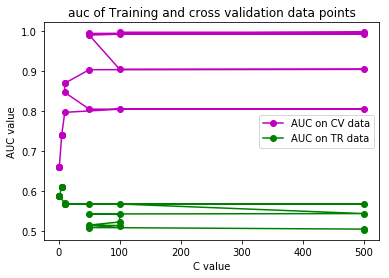

```python
plt.plot([x[0][0][1] for x in tr_list], [x[1] for x in tr_list], linestyle='-', color='m', marker='o',label='AUC on CV data')
plt.plot([x[0][0][1] for x in cv_list], [x[1] for x in cv_list], linestyle='-', color='g', marker='o', label='AUC on TR data')
#plt.plot([0, 1], [0, 1], linestyle='--')
plt.xlabel("C value")
plt.ylabel('AUC value')
plt.title('auc of Training and cross validation data points')
plt.legend()
```

# Optimal Tfidf-W2V- DecesionTree[depth = 5 and splits = 5]

```python
dt = DecisionTreeClassifier(max_depth=5, min_samples_split=5, class_weight='balanced')
dt.fit(xtr, ytr)

ypred = dt.predict_proba(xtest)
ypred_tr = dt.predict_proba(xtr)


fpr_tr, tpr_tr, thresholds_tr= roc_curve(ytr, ypred_tr[:,1])
auc_tr = auc(fpr_tr, tpr_tr)


fpr_test, tpr_test, thresholds_test= roc_curve(ytest, ypred[:,1])
auc_test = auc(fpr_test, tpr_test)

print(auc_test)
```

```
0.5587068010750184
```

*plotting confusion matrix on test data*

```
CPU times: user 0 ns, sys: 0 ns, total: 0 ns
Wall time: 6.44 µs
```

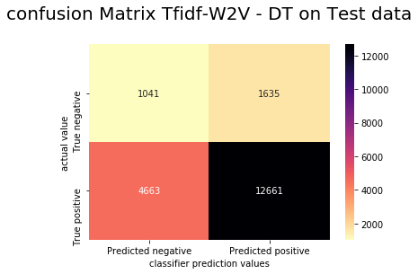

```python
%time
ypred = np.where(ypred[:,1] < 0.5, 0, 1)
#creating confusion matrix:

cf = confusion_matrix(ytest, ypred)
labels = ['True negative', 'True positive']

df_cf = pd.DataFrame(cf, index=labels, columns=['Predicted negative', 'Predicted positive'])
sns.heatmap(df_cf, annot=True,fmt='3d', cmap='magma_r')

plt.title("confusion Matrix Tfidf-W2V - DT on Test data\n", size=20)
plt.xlabel("classifier prediction values")
plt.ylabel("actual value")
plt.show()
```

*plotting confusion matrix on training data*

```
CPU times: user 0 ns, sys: 0 ns, total: 0 ns
Wall time: 6.44 µs
```

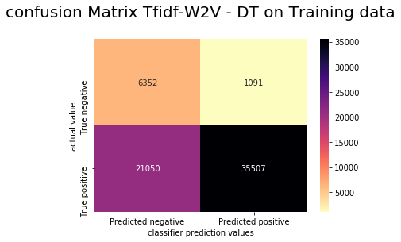

```python
%time
y_pred_tr = np.where(ypred_tr[:,1] < 0.5, 0, 1)
#creating confusion matrix:

cf = confusion_matrix(ytr, y_pred_tr)
labels = ['True negative', 'True positive']

df_cf = pd.DataFrame(cf, index=labels, columns=['Predicted negative', 'Predicted positive'])
sns.heatmap(df_cf, annot=True,fmt='3d', cmap='magma_r')

plt.title("confusion Matrix Tfidf-W2V - DT on Training data\n", size=20)
plt.xlabel("classifier prediction values")
plt.ylabel("actual value")
plt.show()
```

*plotting ROC curve on test data and training data*

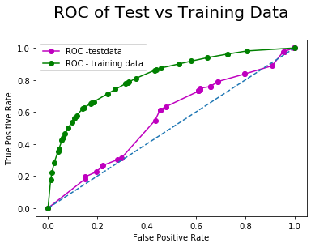

```python
plt.plot(fpr_test, tpr_test, color='m', marker='o',label='ROC -testdata')
plt.plot([0, 1], [0, 1], linestyle='--')
plt.plot(fpr_tr, tpr_tr, linestyle='-', color='g', marker='o', label='ROC - training data')
plt.xlabel('False Positive Rate')
plt.ylabel('True Positive Rate')
plt.title('ROC of Test vs Training Data\n', size=20)
plt.legend()
```

# Decision Tree classifier performance consolidation of 4 vectorizers

```python
perf_dict = dict(algorithm = ['Bow', 'Tfidf', 'W2V', 'Tfidf-W2V'],
                AUC = [0.846, 0.795, 0.661, 0.558],
                Depth = [50, 50, 5, 5],
                Splits =[500, 500, 100, 5])

perf_df = pd.DataFrame(perf_dict)
perf_df
```

|  | AUC | Depth | Splits | algorithm |
| --- | --- | --- | --- | --- |
| 0 | 0.846 | 50 | 500 | Bow |
| 1 | 0.795 | 50 | 500 | Tfidf |
| 2 | 0.661 | 5 | 100 | W2V |
| 3 | 0.558 | 5 | 5 | Tfidf-W2V |